# NC Dynamic View Test

Dan Flynn

2020-06-15

## 2020 Test

Assess if the dynamic view of the North Carolina data in Redshift is done correctly.

- Query NC data for 2020 in dynamic view, `dw_waze.v_alert_geofence_northcarolina`
- Plot over state borders from census file
- Query NC data for 2020 from standard view, `dw_waze.alert`
- Repeat for some months in 2017 for comparison

```r
alert_query_NC <- "SELECT * FROM dw_waze.v_alert_geofence_northcarolina
                    WHERE pub_utc_timestamp BETWEEN to_timestamp('2020-01-01 00:00:00','YYYY-MM-DD HH24:MI:SS')
                                          AND     to_timestamp('2020-05-31 23:59:59','YYYY-MM-DD HH24:MI:SS')
                      " # end query.

system.time(results <- dbGetQuery(conn, alert_query_NC))
```

```
##    user  system elapsed
##  93.470  11.974 125.447
```

```r
save(file = '~/tempout/NC_view_test.RData', list = 'results')
dim(results)
```

```
## [1] 6864560      27
```

```r
alert_query_NC2 <- "SELECT * FROM dw_waze.alert
                    WHERE state='NC'
                    AND pub_utc_timestamp BETWEEN to_timestamp('2020-01-01 00:00:00','YYYY-MM-DD HH24:MI:SS')
                                          AND     to_timestamp('2020-05-31 23:59:59','YYYY-MM-DD HH24:MI:SS')
                      " # end query.

system.time(results2 <- dbGetQuery(conn, alert_query_NC2))
```

```
##    user  system elapsed
##  72.260  11.738  90.324
```

```r
save(file = '~/tempout/NC_view_test2.RData', list = 'results2')
dim(results2)
```

```
## [1] 6965562      27
```

```r
proj.USGS <- "+proj=aea +lat_1=29.5 +lat_2=45.5 +lat_0=23 +lon_0=-96 +x_0=0 +y_0=0 +datum=NAD83 +units=m +no_defs +ellps=GRS80 +towgs84=0,0,0"

co <- readOGR(file.path('~/workingdata', "census"), layer = "cb_2017_us_county_500k")
co <- spTransform(co, CRS(proj.USGS))

# Subset to NC
FIPS_i = formatC(state.fips[state.fips$abb == 'NC', "fips"][1], width = 2, flag = "0")
co_i <- co[co$STATEFP == FIPS_i,]


# Make NC data into spatial points data frame
results$location_lat <- as.numeric(results$location_lat)
results$location_lon <- as.numeric(results$location_lon)

spdf <- SpatialPointsDataFrame(results[,c('location_lon', 'location_lat')],
                               results[,c('alert_uuid', 'alert_type','sub_type','street','city','state','location_lat','location_lon',
                                      'pub_millis')],
                              proj4string = CRS("+proj=longlat +datum=WGS84"))

spdf <-spTransform(spdf, CRS(proj.USGS))
```

Count how many points are out of the census file vs inside

```r
spdf_co <- over(spdf, co_i[c("STATEFP", "COUNTYFP")])
spdf_in <- spdf[!is.na(spdf_co$COUNTYFP),]
spdf_out <- spdf[is.na(spdf_co$COUNTYFP),]

cat(paste(nrow(spdf_in), 'observations in, or \n'), paste(round(nrow(spdf_in)/nrow(spdf)*100, 2), 'percent in \n'),
      paste(nrow(spdf_out), 'observations out, or \n'), paste(round(nrow(spdf_out)/nrow(spdf)*100, 2), 'percent out'))
```

```
## 6860441 observations in, or
##  99.94 percent in
##  4119 observations out, or
##  0.06 percent out
```

Using a 2017 census shapefile, 6,860,441 of the observations (99.94%) where contained in the state boundaries. There were 4,119 observations (0.06%) outside of the state boundaries.

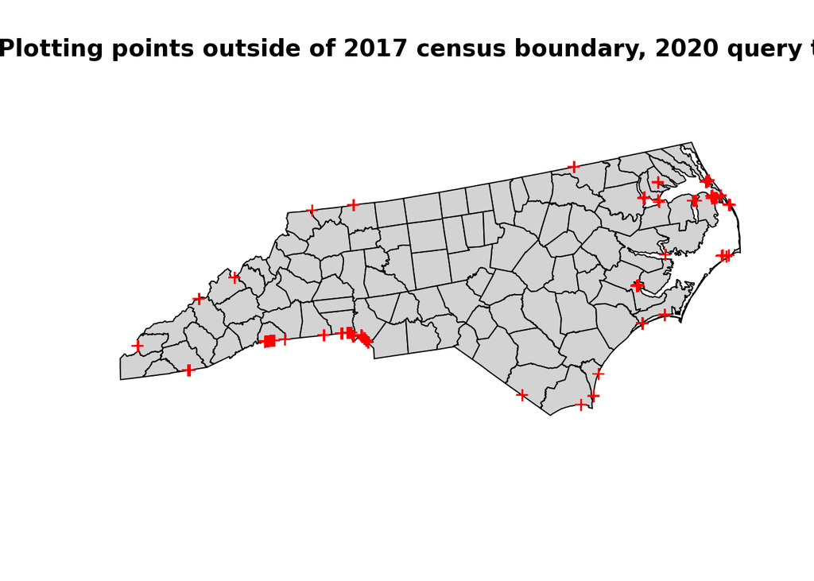

```r
plot(co_i, col = 'lightgrey')
points(spdf_out, pch = '+', col = 'red')
title(main = 'Plotting points outside of 2017 census boundary, 2020 query test')
```

For these points outside of the 2017 state boundary, and which have a city named, some points do in fact appear to be in South Carolina. Others are correctly in North Carolina, and the discrepancy is likely due only to the difference in the definition of the borders for the shapefiles used in defining the dynamic view.

```r
print(sort(table(spdf_out$city), decreasing = T))
```

```
##
##         Lake Wylie, SC          Fort Mill, SC       Emerald Isle, NC
##                    892                    264                     84
##      Morehead City, NC     Atlantic Beach, NC         James City, NC
##                     16                     11                      8
##          Pineville, NC             Clover, SC         Kure Beach, NC
##                      5                      4                      4
##            Belmont, NC           New Bern, NC         Oak Island, NC
##                      3                      3                      2
## Wrightsville Beach, NC
##                      1
```

## 2017 Test

```r
alert_query_NC <- "SELECT * FROM dw_waze.v_alert_geofence_northcarolina
                    WHERE pub_utc_timestamp BETWEEN to_timestamp('2017-05-01 00:00:00','YYYY-MM-DD HH24:MI:SS')
                                          AND     to_timestamp('2017-09-30 23:59:59','YYYY-MM-DD HH24:MI:SS')
                      " # end query.

system.time(results <- dbGetQuery(conn, alert_query_NC))
```

```
##    user  system elapsed
##  69.913  11.526 105.089
```

```r
save(file = '~/tempout/NC_view_test_2017.RData', list = 'results')
dim(results)
```

```
## [1] 5931129      27
```

```r
alert_query_NC2 <- "SELECT * FROM dw_waze.alert
                    WHERE state='NC'
                    AND pub_utc_timestamp BETWEEN to_timestamp('2020-01-01 00:00:00','YYYY-MM-DD HH24:MI:SS')
                                          AND     to_timestamp('2020-05-31 23:59:59','YYYY-MM-DD HH24:MI:SS')
                      " # end query.

system.time(results2 <- dbGetQuery(conn, alert_query_NC2))
```

```
##    user  system elapsed
##  69.903  12.139  88.743
```

```r
save(file = '~/tempout/NC_view_test_20172.RData', list = 'results2')
dim(results2)
```

```
## [1] 6965562      27
```

Querying from 2017-05-01 to 2017-09-30 results in a data frame with 27 columns and 5,931,129 rows.

```r
proj.USGS <- "+proj=aea +lat_1=29.5 +lat_2=45.5 +lat_0=23 +lon_0=-96 +x_0=0 +y_0=0 +datum=NAD83 +units=m +no_defs +ellps=GRS80 +towgs84=0,0,0"

co <- readOGR(file.path('~/workingdata', "census"), layer = "cb_2017_us_county_500k")
co <- spTransform(co, CRS(proj.USGS))

# Subset to NC
FIPS_i = formatC(state.fips[state.fips$abb == 'NC', "fips"][1], width = 2, flag = "0")
co_i <- co[co$STATEFP == FIPS_i,]


# Make NC data into spatial points data frame
results$location_lat <- as.numeric(results$location_lat)
results$location_lon <- as.numeric(results$location_lon)

spdf <- SpatialPointsDataFrame(results[,c('location_lon', 'location_lat')],
                               results[,c('alert_uuid', 'alert_type','sub_type','street','city','state','location_lat','location_lon',
                                      'pub_millis')],
                              proj4string = CRS("+proj=longlat +datum=WGS84"))

spdf <-spTransform(spdf, CRS(proj.USGS))
```

Count how many points are out of the census file vs inside

```r
spdf_co <- over(spdf, co_i[c("STATEFP", "COUNTYFP")])
spdf_in <- spdf[!is.na(spdf_co$COUNTYFP),]
spdf_out <- spdf[is.na(spdf_co$COUNTYFP),]
```

Using a 2017 census shapefile, 5,926,011 of the observations (99.91%) where contained in the state boundaries. There were 5,118 observations (0.09%) outside of the state boundaries.

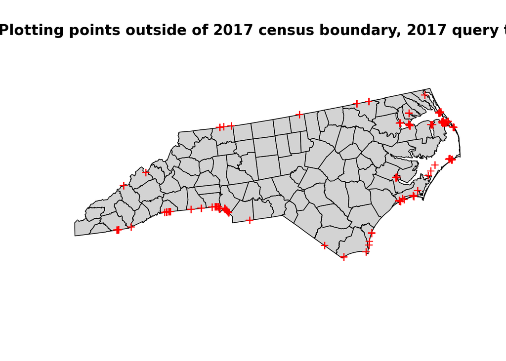

```r
plot(co_i, col = 'lightgrey')
points(spdf_out, pch = '+', col = 'red')
title(main = 'Plotting points outside of 2017 census boundary, 2017 query test')
```

Count of these points outside of the 2017 state boundary, and which have a city named:

```r
print(sort(table(spdf_out$city), decreasing = T))
```

```
##
##         Lake Wylie, SC       Emerald Isle, NC         James City, NC
##                    474                     73                     32
##      Morehead City, NC     Atlantic Beach, NC           New Bern, NC
##                     24                     21                     10
##           Columbus, NC             Clover, SC          Fort Mill, SC
##                      8                      6                      3
##          Charlotte, NC               Cana, VA     Carolina Beach, NC
##                      2                      1                      1
## Wrightsville Beach, NC
##                      1
```